# Loan default prediction

## Context

A major proportion of retail bank profit comes from interests in the form of home loans. These loans are borrowed by regular income/high-earning customers. Banks are most fearful of defaulters, as bad loans (NPA) usually eat up a major chunk of their profits. Therefore, it is important for banks to be judicious while approving loans for their customer base. The approval process for the loans is multifaceted. Through this process, the bank tries to check the creditworthiness of the applicant on the basis of a manual study of various aspects of the application. The entire process is not only effort-intensive but also prone to wrong judgment/approval owing to human error and biases. There have been attempts by many banks to automate this process by using heuristics. But with the advent of data science and machine learning, the focus has shifted to building machines that can learn this approval process and make it free of biases and more efficient. At the same time, one important thing to keep in mind is to make sure that the machine does not learn the biases that previously crept in because of the human approval process.

## Problem Statement

A bank's consumer credit department aims to simplify the decision-making process for home equity lines of credit to be accepted. To do this, they will adopt the Equal Credit Opportunity Act's guidelines to establish an empirically derived and statistically sound model for credit scoring. The model will be based on the data obtained via the existing loan underwriting process from recent applicants who have been given credit. The model will be built from predictive modeling techniques, but the model created must be interpretable enough to provide a justification for any adverse behavior (rejections).

## Objective

Build a classification model to predict clients who are likely to default on their loan and give recommendations to the bank on the important features to consider while approving a loan.

## Data Dictionary

The Home Equity dataset (HMEQ) contains baseline and loan performance information for recent home equity loans. The target (BAD) is a binary variable that indicates whether an applicant has ultimately defaulted or has been severely delinquent. There are 12 input variables registered for each applicant.

- **BAD:** 1 = Client defaulted on loan, 0 = loan repaid
- **LOAN:** Amount of loan approved
- **MORTDUE:** Amount due on the existing mortgage
- **VALUE:** Current value of the property
- **REASON:** Reason for the loan request (HomeImp = home improvement, DebtCon= debt consolidation which means taking out a new loan to pay off other liabilities and consumer debts)
- **JOB:** The type of job that loan applicant has such as manager, self, etc.
- **YOJ:** Years at present job
- **DEROG:** Number of major derogatory reports (which indicates serious delinquency or late payments).
- **DELINQ:** Number of delinquent credit lines (a line of credit becomes delinquent when a borrower does not make the minimum required payments 30 to 60 days past the day on which the payments were due)
- **CLAGE:** Age of the oldest credit line in months
- **NINQ:** Number of recent credit inquiries
- **CLNO:** Number of existing credit lines
- **DEBTINC:** Debt-to-income ratio (all monthly debt payments divided by gross monthly income. This number is one of the ways lenders measure a borrower’s ability to manage the monthly payments to repay the money they plan to borrow)

Click on any heading to jump straight to the content

Data Overview

Exploratory Data Analysis (EDA)

- Analyzing demography
- Analyzing loan related information
- Analyzing overall credit information

Data preprocesing

- Imputing missing values
- Treating outliers

Data preparation

Model evaluation criterion

Building a Decision Tree model

Model Performance evaluation and improvement

Building a Random Forest model

Model Performance evaluation and improvement

Building a logistic regression model

Model Performance evaluation and improvement

Model performance comparison

Actionable Insights and Recommendations

## Importing libraries

```python
#Importing libraries for data manipulation and visualization
import pandas as pd
import numpy as np
import matplotlib.pyplot as plt
import seaborn as sns

# Algorithms to use
from sklearn.model_selection import train_test_split
from sklearn.tree import DecisionTreeClassifier
from sklearn import tree
from sklearn.ensemble import RandomForestClassifier

# Metrics to evaluate the model
from sklearn.metrics import confusion_matrix, classification_report,f1_score, recall_score, precision_score, accuracy_score
from sklearn import metrics

# For hyperparameter tuning
from sklearn.model_selection import GridSearchCV
# Imputing values algorithm
from sklearn.impute import SimpleImputer

# Logistic regression algorithm
from sklearn.linear_model import LogisticRegression
from sklearn.preprocessing import StandardScaler

# To ignore warnings
import warnings
warnings.filterwarnings("ignore")
```

## Data overview

```python
# Importing csv file
data = pd.read_csv('hmeq.csv')
# Let's check first values in dataset
data.head()
```

|  | BAD | LOAN | MORTDUE | VALUE | REASON | JOB | YOJ | DEROG | DELINQ | CLAGE | NINQ | CLNO | DEBTINC |
| --- | --- | --- | --- | --- | --- | --- | --- | --- | --- | --- | --- | --- | --- |
| 0 | 1 | 1100 | 25860.0 | 39025.0 | HomeImp | Other | 10.5 | 0.0 | 0.0 | 94.366667 | 1.0 | 9.0 | NaN |
| 1 | 1 | 1300 | 70053.0 | 68400.0 | HomeImp | Other | 7.0 | 0.0 | 2.0 | 121.833333 | 0.0 | 14.0 | NaN |
| 2 | 1 | 1500 | 13500.0 | 16700.0 | HomeImp | Other | 4.0 | 0.0 | 0.0 | 149.466667 | 1.0 | 10.0 | NaN |
| 3 | 1 | 1500 | NaN | NaN | NaN | NaN | NaN | NaN | NaN | NaN | NaN | NaN | NaN |
| 4 | 0 | 1700 | 97800.0 | 112000.0 | HomeImp | Office | 3.0 | 0.0 | 0.0 | 93.333333 | 0.0 | 14.0 | NaN |

Let's rename target variable column name for 'defaulted' and change all column names to lowercase for convinience.

```python
# Change column names to lowercase
data.columns = data.columns.str.lower()
```

```python
# Renaming target column name
data.rename(columns= {'bad': 'defaulted',
                      'value': 'property_value',
                      'delinq': 'delinq_cl',
                      'clage': 'oldest_cl',
                      'ninq': 'cred_inqs',
                      'clno': 'existin_cl',
                      'debtinc': 'ratio_debtinc'
                     }, inplace=True)

# Changing target outputs for Yes and No
data['defaulted'].replace([1, 0], ['Yes', 'No'], inplace=True)
```

At first sight we notice a lot of missing values.

```python
# Let's check overall data information
data.info()
```

```
<class 'pandas.core.frame.DataFrame'>
RangeIndex: 5960 entries, 0 to 5959
Data columns (total 13 columns):
 #   Column          Non-Null Count  Dtype
---  ------          --------------  -----
 0   defaulted       5960 non-null   object
 1   loan            5960 non-null   int64
 2   mortdue         5442 non-null   float64
 3   property_value  5848 non-null   float64
 4   reason          5708 non-null   object
 5   job             5681 non-null   object
 6   yoj             5445 non-null   float64
 7   derog           5252 non-null   float64
 8   delinq_cl       5380 non-null   float64
 9   oldest_cl       5652 non-null   float64
 10  cred_inqs       5450 non-null   float64
 11  existin_cl      5738 non-null   float64
 12  ratio_debtinc   4693 non-null   float64
dtypes: float64(9), int64(1), object(3)
memory usage: 605.4+ KB
```

There are 13 columns in our dataset for which only Bad and Loan columns does not contain missing values. There are only three categorical columns in the dataset (Reason, Job and Bad).

Next, let's check print a quick statistical summary.

```python
# Printing statistical summary for numerical variables
data.describe().T.round(2)
```

|  | count | mean | std | min | 25% | 50% | 75% | max |
| --- | --- | --- | --- | --- | --- | --- | --- | --- |
| loan | 5960.0 | 18607.97 | 11207.48 | 1100.00 | 11100.00 | 16300.00 | 23300.00 | 89900.00 |
| mortdue | 5442.0 | 73760.82 | 44457.61 | 2063.00 | 46276.00 | 65019.00 | 91488.00 | 399550.00 |
| property_value | 5848.0 | 101776.05 | 57385.78 | 8000.00 | 66075.50 | 89235.50 | 119824.25 | 855909.00 |
| yoj | 5445.0 | 8.92 | 7.57 | 0.00 | 3.00 | 7.00 | 13.00 | 41.00 |
| derog | 5252.0 | 0.25 | 0.85 | 0.00 | 0.00 | 0.00 | 0.00 | 10.00 |
| delinq_cl | 5380.0 | 0.45 | 1.13 | 0.00 | 0.00 | 0.00 | 0.00 | 15.00 |
| oldest_cl | 5652.0 | 179.77 | 85.81 | 0.00 | 115.12 | 173.47 | 231.56 | 1168.23 |
| cred_inqs | 5450.0 | 1.19 | 1.73 | 0.00 | 0.00 | 1.00 | 2.00 | 17.00 |
| existin_cl | 5738.0 | 21.30 | 10.14 | 0.00 | 15.00 | 20.00 | 26.00 | 71.00 |
| ratio_debtinc | 4693.0 | 33.78 | 8.60 | 0.52 | 29.14 | 34.82 | 39.00 | 203.31 |

### Observations:

```python
# Printing summary for categorical variables
data.describe(include='O').T
```

|  | count | unique | top | freq |
| --- | --- | --- | --- | --- |
| defaulted | 5960 | 2 | No | 4771 |
| reason | 5708 | 2 | DebtCon | 3928 |
| job | 5681 | 6 | Other | 2388 |

```python
# Creating a list with categorical column names
cat_var = data.select_dtypes('O').columns.tolist()

# Printing a quick summary for categories present
for i in cat_var:
    print(i)
    print('')
    print(data[i].value_counts(normalize=True)*100)
    print('*'*50)
```

```
defaulted

No     80.050336
Yes    19.949664
Name: defaulted, dtype: float64
reason

DebtCon    68.815697
HomeImp    31.184303
Name: reason, dtype: float64
job

Other      42.034853
ProfExe    22.460834
Office     16.687203
Mgr        13.501144
Self        3.397289
Sales       1.918676
Name: job, dtype: float64
```

### Observations:

- Aproximetaly, only 20% of people have been labeled as defaulters.
- Most people, around 69%, have requested a loan for consolidating debts while 31% of them requested a loan for home improvement.
- Job labeled has Other has a frecuency of 42%, followed by ProfeExe and Office with frecuency of 22% and 16%, respectively.

**Detecting missing values in the dataset**

```python
# Creating dataframe with total missing values and its percentage
pd.DataFrame([data.isnull().sum(),
              data.isnull().sum()/data.shape[0]*100],
             index = ['Missing values', 'Percentage']).T
```

|  | Missing values | Percentage |
| --- | --- | --- |
| defaulted | 0.0 | 0.000000 |
| loan | 0.0 | 0.000000 |
| mortdue | 518.0 | 8.691275 |
| property_value | 112.0 | 1.879195 |
| reason | 252.0 | 4.228188 |
| job | 279.0 | 4.681208 |
| yoj | 515.0 | 8.640940 |
| derog | 708.0 | 11.879195 |
| delinq_cl | 580.0 | 9.731544 |
| oldest_cl | 308.0 | 5.167785 |
| cred_inqs | 510.0 | 8.557047 |
| existin_cl | 222.0 | 3.724832 |
| ratio_debtinc | 1267.0 | 21.258389 |

### Observations:

- Only default and loan information columns has no missing values.
- Debt-to-income ratio is the columns with most missing values, 21% of data is missing.

```python
# Setting a list with seaborn color codes
clrs = sns.color_palette("pastel").as_hex()
```

## Exploratory Data Analysis (EDA)

- EDA is an important part of any project involving data.
- It is important to investigate and understand the data better before building a model with it.
- A few questions have been mentioned below which will help you approach the analysis in the right manner and generate insights from the data.
- A thorough analysis of the data, in addition to the questions mentioned below, should be done.

**Leading Questions**:

1. What is the range of values for the loan amount variable "LOAN"?
2. How does the distribution of years at present job "YOJ" vary across the dataset?
3. How many unique categories are there in the REASON variable?
4. What is the most common category in the JOB variable?
5. Is there a relationship between the REASON variable and the proportion of applicants who defaulted on their loan?
6. Do applicants who default have a significantly different loan amount compared to those who repay their loan?
7. Is there a correlation between the value of the property and the loan default rate?
8. Do applicants who default have a significantly different mortgage amount compared to those who repay their loan?

```python
#Creating a function to plot both boxplot and histogram of numerical varibles
def box_histplot(field, color, title, xlabel, mean = True, showkde = True, bins='auto'):
    '''
    Function to plot a boxplot and a histplot from numerical varible
    with vertical ratio of 0.25, 0.75, respectively.

    field: Numerical column to plot
    color: hex color code for both plots
    title: title for specific plot
    xlabel: specific label for the x axis
    '''
    fig,ax = plt.subplots(2,1, figsize=(8,5), gridspec_kw={'height_ratios': [0.25, 0.75]}, sharex=True)

    sns.boxplot(data=data, x=field, showmeans= mean, color= color,ax=ax[0])
    sns.histplot(data=data, x=field, bins=bins, kde = showkde, color = color,ax=ax[1])

    # Add mean to the histogram
    ax[1].axvline(data[field].mean(), color = "green", linestyle = "--")
    # Add median to the histogram
    ax[1].axvline(data[field].median(), color = "black", linestyle = "-")

    fig.suptitle(title)
    ax[0].set(xlabel='')
    ax[1].set(xlabel= xlabel)
    plt.show()
```

### Analyzing demography

We will start the analysis by showing the distribution of the target variable as well as the distribution of clients profession.

```
[Text(0.5, 0, 'Profession'), Text(0, 0.5, '')]
```

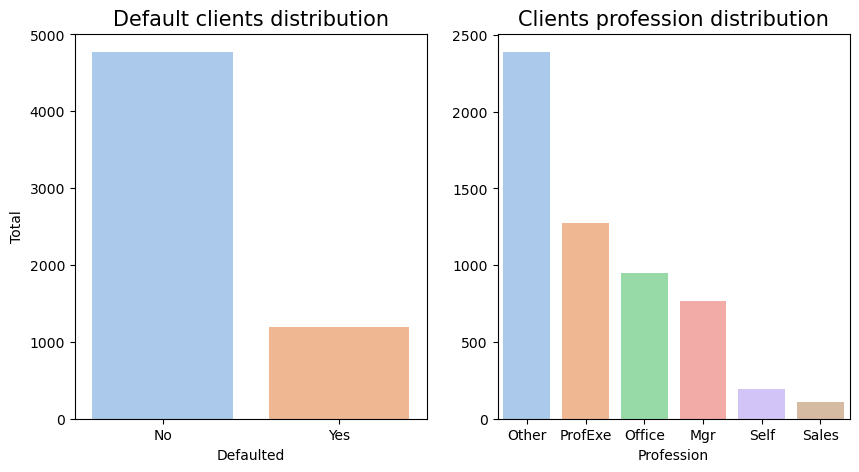

```python
# set dummy variable for job plotting order
jobord = data.job.value_counts().index.tolist()

# Setting figure for plots
fig, ax = plt.subplots(1,2, figsize=(10,5))
# Plotting countplot for clients default and job distribution
sns.countplot(x=data.defaulted, ax =ax[0], palette = 'pastel', order = ['No', 'Yes'])
sns.countplot(x=data.job,palette='pastel', order=jobord, ax=ax[1])
# Setting figure and axes titles
ax[0].set_title('Default clients distribution', fontsize=15)
ax[0].set(xlabel='Defaulted', ylabel='Total')
ax[1].set_title('Clients profession distribution', fontsize=15)
ax[1].set(xlabel='Profession', ylabel='')
```

```python
# printing defaulted status grouped by jobs
data.groupby('job')['defaulted'].value_counts(normalize=True)
```

```
job      defaulted
Mgr      No           0.766623
         Yes          0.233377
Office   No           0.868143
         Yes          0.131857
Other    No           0.768007
         Yes          0.231993
ProfExe  No           0.833856
         Yes          0.166144
Sales    No           0.651376
         Yes          0.348624
Self     No           0.699482
         Yes          0.300518
Name: defaulted, dtype: float64
```

Next, let's proceed visualizing the years in current job and the debt-to-income ratio distributions.

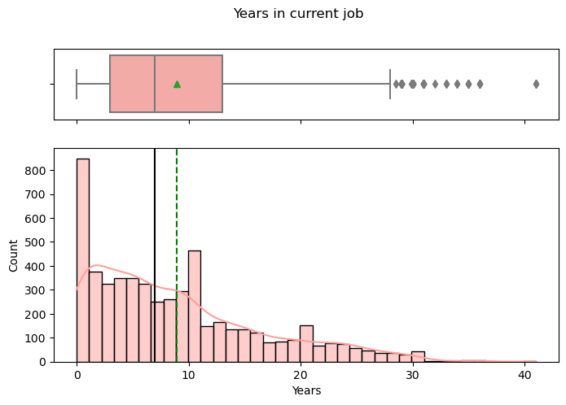

```python
# Visualizing distribution of people's years in current job
box_histplot('yoj', clrs[3], 'Years in current job', 'Years')
```

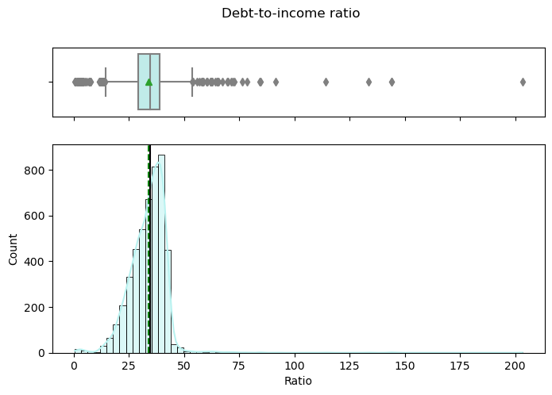

```python
# Visualizing distribution of debt-to-income ratio
box_histplot('ratio_debtinc', clrs[9], 'Debt-to-income ratio', 'Ratio',bins=70)
```

Now we can plot how the mean debt-to-income ratio varies depending on the job in order to see if there is any visible pattern.

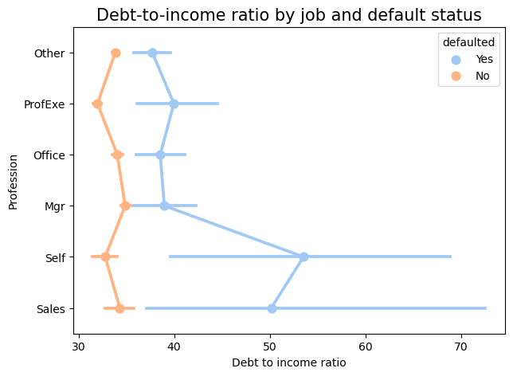

```python
# Setting figure
plt.figure(figsize=(7,5))
# Plotting debt-to-income ratio vs job and defaulted
sns.pointplot(data=data, x="ratio_debtinc", y="job", hue="defaulted", order=jobord, palette='pastel')
plt.title('Debt-to-income ratio by job and default status', fontsize=15)
plt.xlabel('Debt to income ratio')
plt.ylabel('Profession')
plt.show()
```

### Observations:

- The majority of clients are not defaulters, as it was previously stated around 20% of clientes turned out to be defaulters.
- Regarding job distribution, most clients job is labeled as Others while the profession with least clients is Sales.
- With respect of people years in their current job, it shows a right-skewed distribution with a mean of nearly 9 years. Very few people in the dataset has more than 28 years in their current job.
- In terms of debt-to-income ratio, the average person has a debt of 33 times their income. In this case, few people has a debt of half their income, meaning they perceive an income of twice their debt. On the other hand, few people has a debt of 53 times their income, and only one person has a debt of 203 times its income.
- Respecting the last plot, we notice that in every job category the clients that paid their loans has in average a smaller debt-to-income ratio. On the other hand, despite Sales and Self, being the categories with least clients, people in this categories who turn out to be defaulters has a considerably higher debt-to-income ratio.

### Loan related information

Let's continue the analysis by looking at the loan related information such as the loan aproved amount, the due amount of the existing mortgage and the distribution of property values.

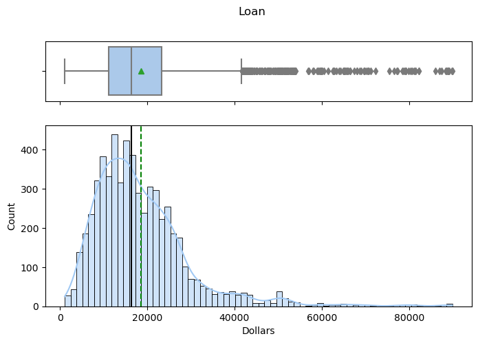

```python
# Visualizing the loaned amount in dollars
box_histplot('loan', clrs[0], 'Loan', 'Dollars')
```

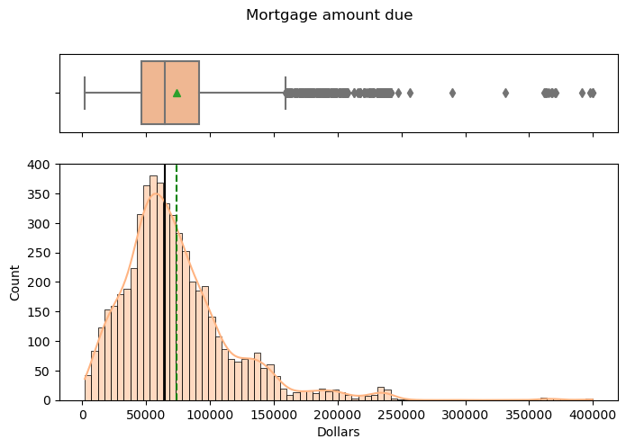

```python
# Visualizing the amount due of the existing mortgage
box_histplot('mortdue', clrs[1], 'Mortgage amount due', 'Dollars')
```

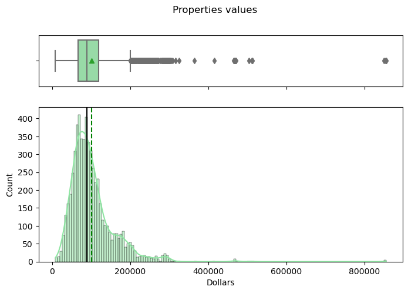

```python
# Visualizing distribution of properties values
box_histplot('property_value', clrs[2], 'Properties values', 'Dollars')
```

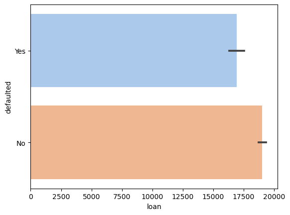

```python
# Ploting the mean loan approved regarding the defaulted status
sns.barplot(data=data, x='loan', y='defaulted', palette='pastel')
```

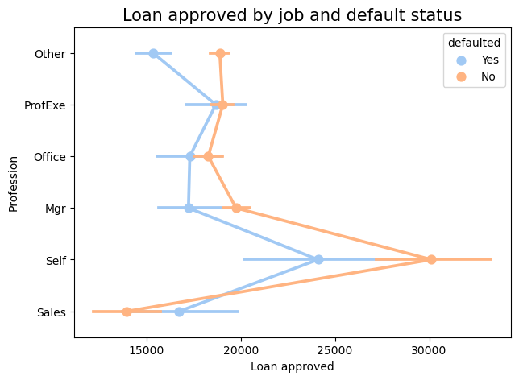

```python
# Setting figure
plt.figure(figsize=(7,5))
# Plotting loan approved ratio vs job and defaulted
sns.pointplot(data=data, x="loan", y='job', hue = 'defaulted', order=jobord, palette='pastel')
plt.title('Loan approved by job and default status', fontsize=15)
plt.xlabel('Loan approved')
plt.ylabel('Profession')
plt.show()
```

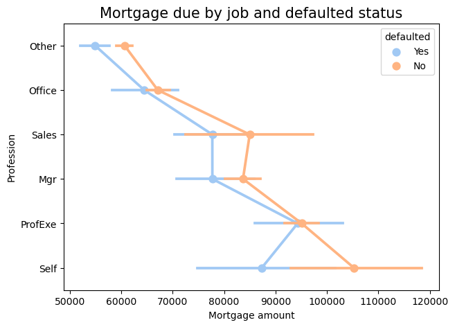

```python
# Setting figure
plt.figure(figsize=(7,5))
# Plotting mortgage due vs job and defaulted
sns.pointplot(data=data, x="mortdue", y='job', hue = 'defaulted', palette='pastel')
plt.title('Mortgage due by job and defaulted status', fontsize=15)
plt.xlabel('Mortgage amount')
plt.ylabel('Profession')
plt.show()
```

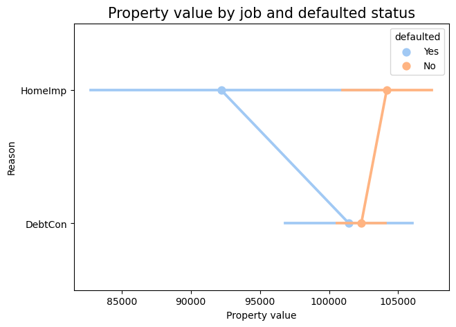

```python
# Setting figure
plt.figure(figsize=(7,5))
# Plotting property value ratio vs reason and defaulted
sns.pointplot(data=data, x="property_value", y='reason', hue = 'defaulted', palette='pastel')
plt.title('Property value by job and defaulted status', fontsize=15)
plt.xlabel('Property value')
plt.ylabel('Reason')
plt.show()
```

Next, it is plotted the mean loan approved with respect to jobs, as well as the mean mortgage due and mean property value depending on the job and reason of loan.

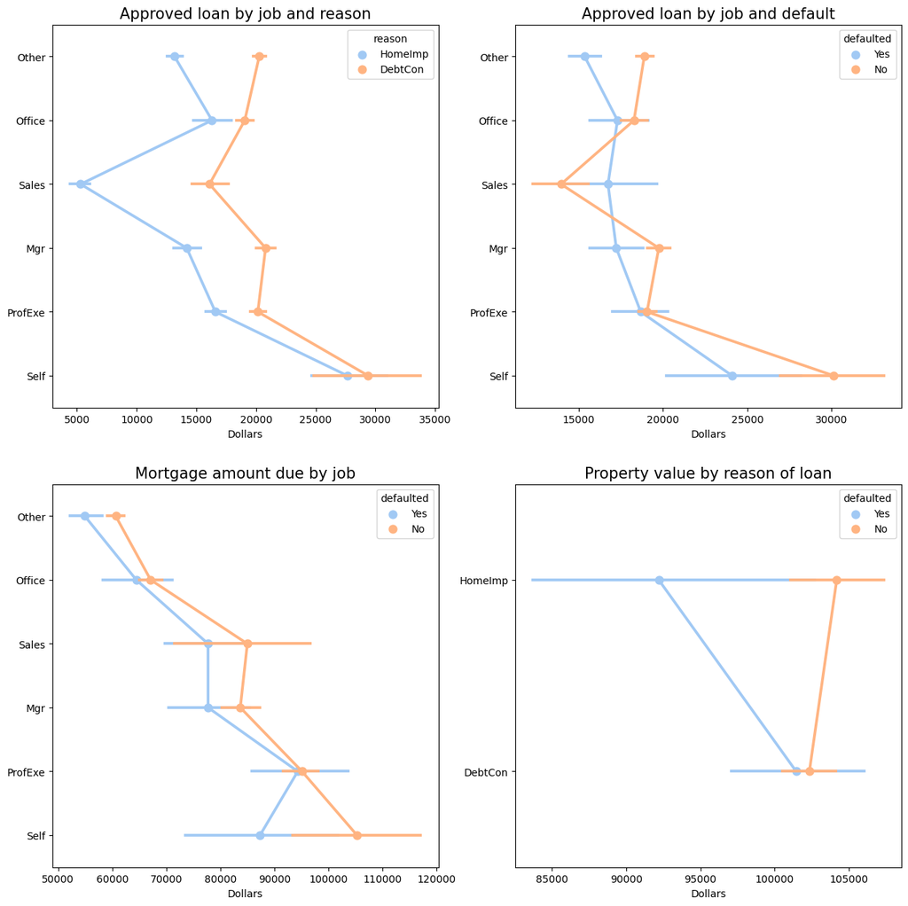

```python
# Dictionary with variables of interest and titles for the plots
varord = {'x_var': ['loan','loan','mortdue', 'property_value'],
          'y_var' : ['job', 'job', 'job', 'reason'],
          'hue' : ['reason', 'defaulted', 'defaulted', 'defaulted'],
          'title': ['Approved loan by job and reason', 'Approved loan by job and default',
                   'Mortgage amount due by job', 'Property value by reason of loan']}

# Setting subplots
c=0
fig, ax = plt.subplots(2,2, figsize=(15,15))
for i in range(2):
    c=c+i
    for j in range(2):
        c = c+j
        # Plotting variables of interest
        sns.pointplot(data=data, x= varord['x_var'][c], y=varord['y_var'][c] , hue=varord['hue'][c],
                      palette ='pastel',ax=ax[i][j])

        ax[i][j].set_title(varord['title'][c], fontsize=15)
        ax[i][j].set(xlabel='Dollars')
        ax[i][j].set(ylabel='')
```

### Overall credit information

Let's continue by analyzing credit information such as the antiquity of the oldest credit line, number of existing credit lines, derogatory reports and the number of delinquent credit lines.

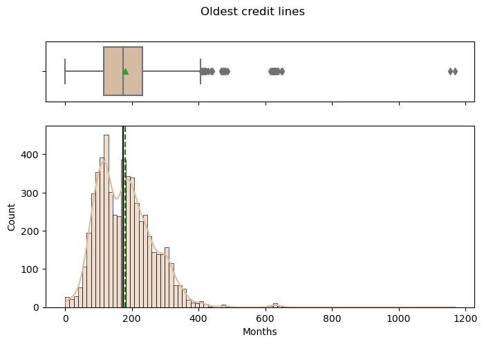

```python
# Visualizing distribution of oldest credit lines
box_histplot('oldest_cl', clrs[5], 'Oldest credit lines', 'Months')
```

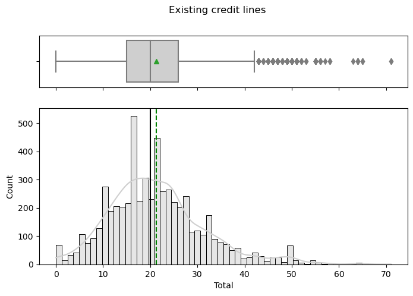

```python
# Visualizing distribution of existing credit lines
box_histplot('existin_cl', clrs[7], 'Existing credit lines', 'Total')
```

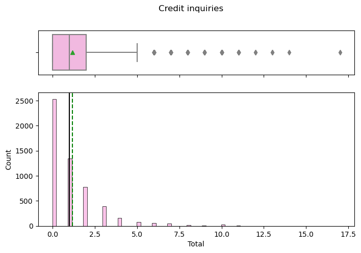

```python
# Visualizing distribution of number of credit inquiries
box_histplot('cred_inqs', clrs[6], 'Credit inquiries', 'Total', True, False)
```

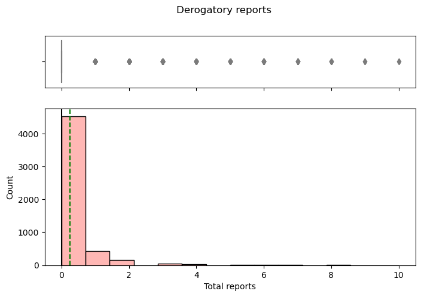

```python
# Visualizing number of derogatory reports
box_histplot('derog', clrs[3], 'Derogatory reports', 'Total reports', mean = False, showkde=False)
```

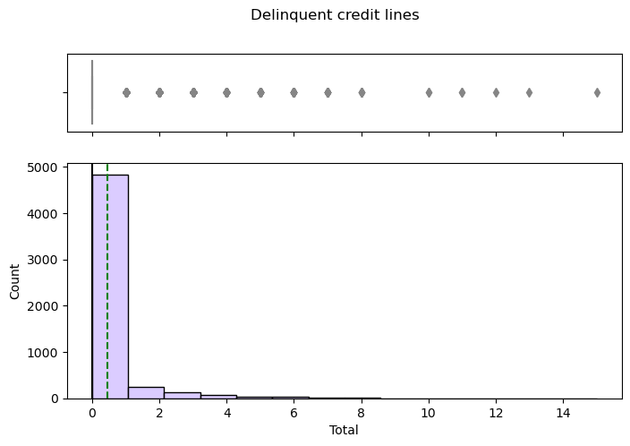

```python
# Visualizing distribution of delinquent credit lines
box_histplot('delinq_cl', clrs[4], 'Delinquent credit lines', 'Total', False, False)
```

In this case, dropna() function is used to ignore null values from the dataset and get information only for those people for which information is available.

```python
# Creating two new categorical variables for the number of derogatory reporst and delinquent credit lines
data['cat_derog'] = data['derog'].dropna().apply(lambda x: 'Yes' if x>0 else 'No' )
data['cat_delinq'] = data['delinq_cl'].dropna().apply(lambda x: 'Yes' if x>0 else 'No')
```

```python
# print quick summary
data[['cat_derog', 'cat_delinq']].describe().T
```

|  | count | unique | top | freq |
| --- | --- | --- | --- | --- |
| cat_derog | 5252 | 2 | No | 4527 |
| cat_delinq | 5380 | 2 | No | 4179 |

As it was previously shown, most people does not have any derogatory report or delinquent credit lines, however it might be important to explore more deeply into these variables since they are indicating signs of late payments.

Hence, we will visualize the default proportion for people who has at least one derogatory report and people with at least one delinquent credit line, as well as people with any. Its important to highlight that next plots are given for people for which we have information of delinq_cl and derog columns.

Let's plot the default distribution for people with derogatory report or delinquent credit lines.

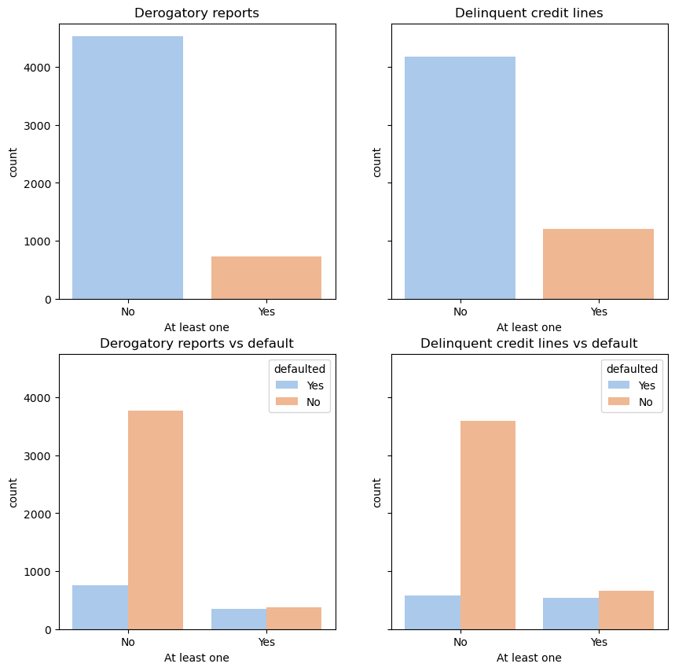

```python
# List with variables of interest and titles for the plots
catvar = {'var': ['cat_derog','cat_delinq'],
          'hue': [None, 'defaulted'],
          'title': ['Derogatory reports', 'Delinquent credit lines',
                  'Derogatory reports vs default','Delinquent credit lines vs default'] }

# Plotting variables
c=0
fig, ax = plt.subplots(2,2, figsize=(10,10), sharey=True)
for i in range(2):
    c=c+i
    for j in range(2):
        c = c+j
        sns.countplot(data=data,x= catvar['var'][j] ,hue = catvar['hue'][i], palette ='pastel',ax=ax[i][j])
        ax[i][j].set_title(catvar['title'][c])
        ax[i][j].set(xlabel='At least one')
```

```python
# Printing the ratio of people with at least one derogatory report
data['cat_derog'].value_counts(normalize=True)
```

```
No     0.861957
Yes    0.138043
Name: cat_derog, dtype: float64
```

```python
# Printing the ratio of people with at least one delinquent credit line
data['cat_delinq'].value_counts(normalize=True)
```

```
No     0.776766
Yes    0.223234
Name: cat_delinq, dtype: float64
```

```python
# Printing info of people with at least one derogatory report and defaulted status
data.groupby('cat_derog')['defaulted'].value_counts(normalize=True)
```

```
cat_derog  defaulted
No         No           0.833444
           Yes          0.166556
Yes        No           0.520000
           Yes          0.480000
Name: defaulted, dtype: float64
```

```python
# Printing info of people with at least one delinquent credit line and defaulted status
data.groupby('cat_delinq')['defaulted'].value_counts(normalize=True)
```

```
cat_delinq  defaulted
No          No           0.860493
            Yes          0.139507
Yes         No           0.555371
            Yes          0.444629
Name: defaulted, dtype: float64
```

- As stated, most people does not have any derogatory report or delinquent credit line. Only 13% of people has at least one derogatory report, while 22% has at least one credit line labeled as delinquent.
- For people with at least one derogatory report, 48% are labeled as defaulters while 16% of people with no reports are defaulters.
- For people with at least one delinquent credit line, 44% are defaulters, while 13% of people with no delinquent credit lines are defaulters.

Let's check the mean for antiquity of the oldest credit line, the numbre of existing credit lines, number of recent inquiries and their relation with delinquent credit lines as well with the number of derogatory reports.

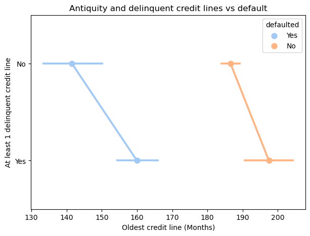

```python
# setting figure for oldest_cl vs cat_delinq and default
plt.figure(figsize=(7,5))
sns.pointplot(data=data, x = 'oldest_cl', y = 'cat_delinq', hue ='defaulted', palette='pastel' )
plt.title('Antiquity and delinquent credit lines vs default')
plt.xlabel('Oldest credit line (Months)')
plt.ylabel('At least 1 delinquent credit line')
```

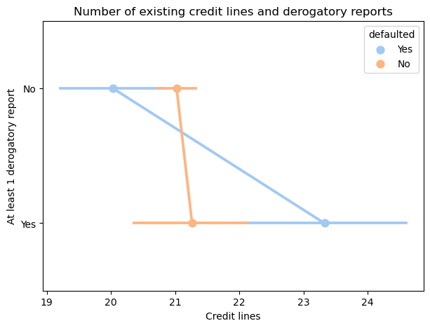

```python
# setting figure for existin_cl vs cat_derog and default
plt.figure(figsize=(7,5))
sns.pointplot(data=data, x = 'existin_cl', y = 'cat_derog', hue ='defaulted', palette='pastel')
plt.title('Number of existing credit lines and derogatory reports')
plt.xlabel('Credit lines')
plt.ylabel('At least 1 derogatory report')
```

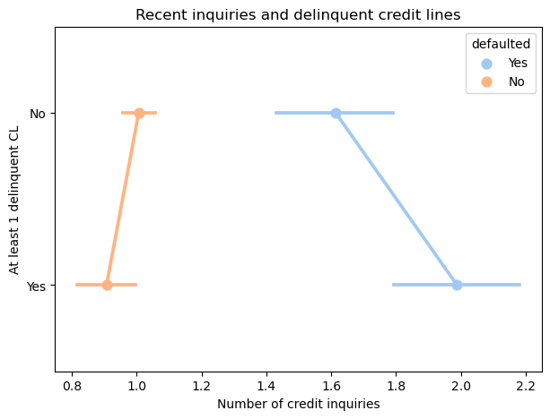

```python
# setting figure for credit_inqs vs cat_derog and default
plt.figure(figsize=(7,5))
sns.pointplot(data=data, x = 'cred_inqs', y = 'cat_delinq', hue ='defaulted', palette='pastel' )
plt.title('Recent inquiries and delinquent credit lines')
plt.xlabel('Number of credit inquiries')
plt.ylabel('At least 1 delinquent CL')
```

- In terms of mean oldest credit line, it seem that defaulters tends to have less antiquity with their oldest credit than those who are not defaulters.
- In average, not default persons have similar number of credit lines for both classes, with or without derogatory reports. On the other hand, people with derogatory reports who are defaulters have in average more credit lines than those who are defaulters but does not have derogatory reports.
- With respect to inquiries, in average defaulters have similar number of inquiries in both classes, with/without delinquent credit, and at the same time have more inquiries than not defaulter people.

### Observations:

- All numerical variables presents outliers which will be deeply inspected and treated in next sections.
- Once again, credit line antiquity shows a right-skewed distribution. Mean and median are relatively close, 179 and 173 months, resepectively. On the other hand, very few people has a credit line antiquity of more than 400 months and even fewer people has a credit line of about 1,160 months (96 years!).
- The number of existing credit lines shows a right-skewed distribution. In average, people counts with 21 credit lines, half the people has less than 20 credit lines and just few people has more than 40 credit lines. Even fewer people has up to 71 credit lines.
- Number of credit inquiries shows a right-skewed distribution. The mean and median are close, aproximately, one inquiry, while few people has more than five inquiries in their record.
- With respect to derogatory reports, which might be one of the most importan features for the target prediction, most of the people has any report, while few people has more than 1 reports and up to 10 reports.
- Once again, very few people has credit lines labeled as delinquent.

**Next, we want to know if there are some kind of correlation between numerical variables.**

```python
# Computing correlation matrix
data.corr()
```

|  | loan | mortdue | property_value | yoj | derog | delinq_cl | oldest_cl | cred_inqs | existin_cl | ratio_debtinc |
| --- | --- | --- | --- | --- | --- | --- | --- | --- | --- | --- |
| loan | 1.000000 | 0.228595 | 0.335393 | 0.105728 | -0.001302 | -0.035144 | 0.088540 | 0.044487 | 0.072631 | 0.084735 |
| mortdue | 0.228595 | 1.000000 | 0.875666 | -0.088480 | -0.049516 | -0.001044 | 0.140047 | 0.031392 | 0.323631 | 0.154939 |
| property_value | 0.335393 | 0.875666 | 1.000000 | 0.007759 | -0.048689 | -0.014103 | 0.171238 | -0.004398 | 0.269149 | 0.132174 |
| yoj | 0.105728 | -0.088480 | 0.007759 | 1.000000 | -0.065879 | 0.038153 | 0.201718 | -0.071627 | 0.024838 | -0.055891 |
| derog | -0.001302 | -0.049516 | -0.048689 | -0.065879 | 1.000000 | 0.211832 | -0.083047 | 0.173934 | 0.061884 | 0.017065 |
| delinq_cl | -0.035144 | -0.001044 | -0.014103 | 0.038153 | 0.211832 | 1.000000 | 0.022488 | 0.067812 | 0.164639 | 0.052364 |
| oldest_cl | 0.088540 | 0.140047 | 0.171238 | 0.201718 | -0.083047 | 0.022488 | 1.000000 | -0.116935 | 0.237987 | -0.046477 |
| cred_inqs | 0.044487 | 0.031392 | -0.004398 | -0.071627 | 0.173934 | 0.067812 | -0.116935 | 1.000000 | 0.088389 | 0.141344 |
| existin_cl | 0.072631 | 0.323631 | 0.269149 | 0.024838 | 0.061884 | 0.164639 | 0.237987 | 0.088389 | 1.000000 | 0.185539 |
| ratio_debtinc | 0.084735 | 0.154939 | 0.132174 | -0.055891 | 0.017065 | 0.052364 | -0.046477 | 0.141344 | 0.185539 | 1.000000 |

We notice a strong positive correlation between the mortgage due and the property value, which makes sense since mortgages approved are proportional to the value of the property. On the other hand, we notice a weak postive correlation between the number of delinquent credit lines and the number of derogatory reports. There is also a weak correlation between the approved loan and the mortgage due as well as between the approved loan and the property value.

**Let's visualize the correlation between mortgage due and the property value.**

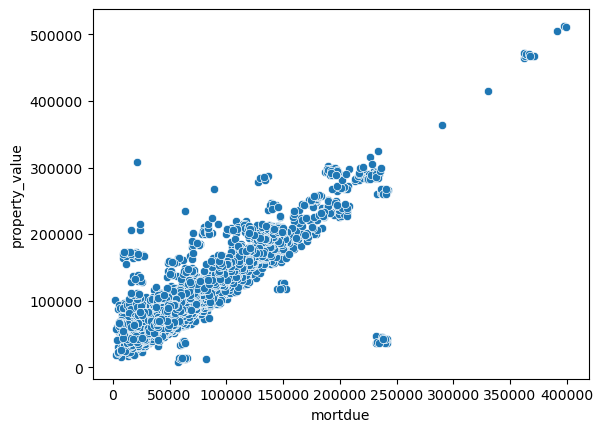

```python
# Plotting mortgage due vs property value.
sns.scatterplot(data=data, x = 'mortdue', y = 'property_value')
```

### Detecting outliers

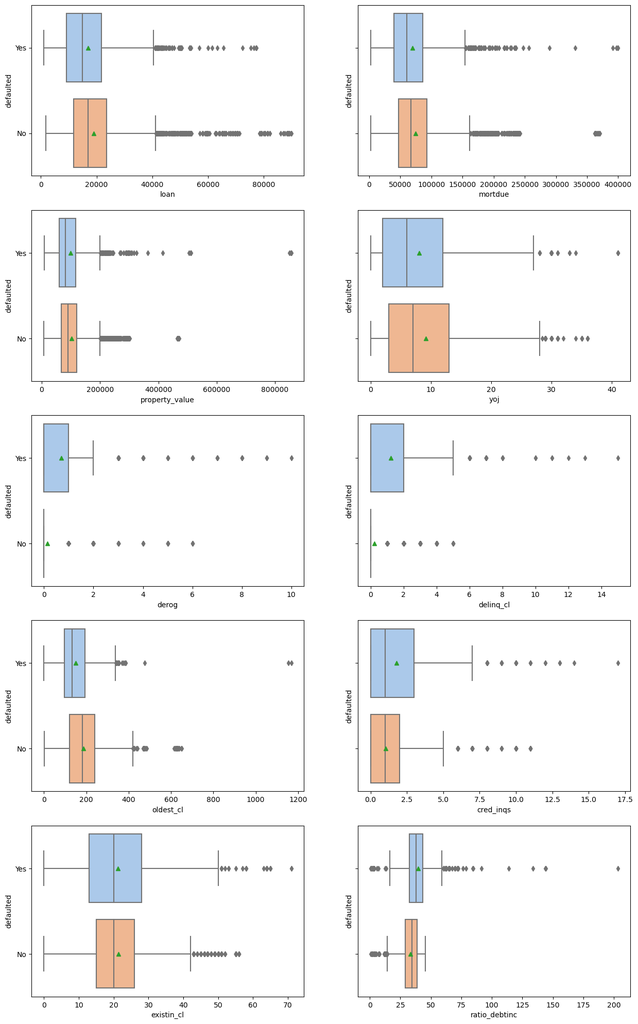

```python
# setting dummy variable to plot multiple box plots
ls = data.select_dtypes(np.number).columns.tolist()
ls = np.array(ls).reshape((5,2))

# Plotting variables
fig, ax = plt.subplots(5,2, figsize=(15,25), sharey=True)
for i in range(2):
    for j in range(5):
        sns.boxplot(data=data, x = data[ls[j,i]] , y ='defaulted', palette ='pastel', showmeans =True, ax=ax[j][i])

#plt.set_title('Visualizing outliers by default', fontsize=15)
```

## Data preprocessing

Once we have analyzed the data, it is time to treat both missing values and outliers in order to implement the classification algorithms. In this case, we want to first impute missing values and then treat outliers, by doing this we aim to treat outliers that imputing values could have done. Otherwise, treating outliers and then missing values will probably lead to treat again outliers after imputing missing values.

In order to compare distribution of variables before and after imputing missing values we need to make a copy of the dataset. At this point, we will drop categorical variables created in previous sections to fit the models with the original dataset.

```python
# Makiing a copy of original dataset
df = data.copy().drop(columns=['cat_derog','cat_delinq'])
```

### Imputing missing values

Recalling the total of missing values and their respective percentage.

```python
# Creating dataframe with total missing values and its percentage
bf_imp = pd.DataFrame([df.isnull().sum(),
              df.isnull().sum()/df.shape[0]*100],
             index = ['Missing values', 'Percentage']).T.sort_values(by='Percentage', ascending=False)
bf_imp
```

|  | Missing values | Percentage |
| --- | --- | --- |
| ratio_debtinc | 1267.0 | 21.258389 |
| derog | 708.0 | 11.879195 |
| delinq_cl | 580.0 | 9.731544 |
| mortdue | 518.0 | 8.691275 |
| yoj | 515.0 | 8.640940 |
| cred_inqs | 510.0 | 8.557047 |
| oldest_cl | 308.0 | 5.167785 |
| job | 279.0 | 4.681208 |
| reason | 252.0 | 4.228188 |
| existin_cl | 222.0 | 3.724832 |
| property_value | 112.0 | 1.879195 |
| defaulted | 0.0 | 0.000000 |
| loan | 0.0 | 0.000000 |

Next, we will impute missing values in some variables with their corresponding median grouped by default and job in order to get a more precise representation of population and to not change significantly the distribution of variables after imputing missing values. The reason behind is that all variables are skewed, moreover we noticed that mean grouped by job for some variables changes significantly and, in other variables, it is clear that the mean grouped by default shows a clear pattern.

**Variables to impute corresponding median grouped by job and default:**

- mortgage due
- property value
- years in job
- oldest credit line
- existing credit lines
- ratio debt-to-income

**Variables to impute corresponding mean grouped by default**

- derogatory reports
- credits inquiries
- delinquent credit lines

**Variables to impute mode**

- job
- reason

In this case, we will proceed to impute values in tree stages as stated above. For categorical variables we will use the SimpleImputer class from Scikit learn. Furthermore, we will start to impute the job and the reason in order to impute all values in other variables.

```python
# creating list with variable names to impute
vars_list1 = ['job', 'reason']
vars_list2 = ['mortdue', 'property_value', 'yoj', 'oldest_cl', 'existin_cl', 'ratio_debtinc']
vars_list3 = ['derog', 'cred_inqs', 'delinq_cl']
```

```python
# setting the imputer algorithm from scikit learn
imp = SimpleImputer(strategy = 'most_frequent')

# imputing mode to missing values
df[vars_list1] = imp.fit_transform(df[vars_list1])
```

```python
# Imputing values of the second list
for i in vars_list2:
    df[i] = df[i].fillna(value = df.groupby(['job','defaulted'])[i].transform('median'))
```

```python
# Imputing values of third list
for i in vars_list3:
    df[i] = df[i].fillna(value = df.groupby(['defaulted'])[i].transform('mean'))
```

Now, let's compare the missing values percentage before and after imputing missing values.

```python
# Creating dataframe with total missing values and its percentage
af_imp = pd.DataFrame([df.isnull().sum(),
              df.isnull().sum()/df.shape[0]*100],
             index = ['Missing values', 'Percentage']).T.sort_values(by='Percentage', ascending=False)
```

```python
# Joining both dataframes
pd.concat([bf_imp, af_imp], axis=1)
```

|  | Missing values | Percentage | Missing values | Percentage |
| --- | --- | --- | --- | --- |
| ratio_debtinc | 1267.0 | 21.258389 | 0.0 | 0.0 |
| derog | 708.0 | 11.879195 | 0.0 | 0.0 |
| delinq_cl | 580.0 | 9.731544 | 0.0 | 0.0 |
| mortdue | 518.0 | 8.691275 | 0.0 | 0.0 |
| yoj | 515.0 | 8.640940 | 0.0 | 0.0 |
| cred_inqs | 510.0 | 8.557047 | 0.0 | 0.0 |
| oldest_cl | 308.0 | 5.167785 | 0.0 | 0.0 |
| job | 279.0 | 4.681208 | 0.0 | 0.0 |
| reason | 252.0 | 4.228188 | 0.0 | 0.0 |
| existin_cl | 222.0 | 3.724832 | 0.0 | 0.0 |
| property_value | 112.0 | 1.879195 | 0.0 | 0.0 |
| defaulted | 0.0 | 0.000000 | 0.0 | 0.0 |
| loan | 0.0 | 0.000000 | 0.0 | 0.0 |

Once we have imputed missing values it is time to treat ouliers.

### Treating outliers

As previously mentioned, variables have clear patterns when grouped by default category. Thus, we will clip outliers for all numerical variables grouped by default and compare the distributions after clipping.

```python
# setting dummy list with number of numerical variables
dv = df.select_dtypes(np.number).columns.tolist()

# Clipping outliers to upper and lower whiskers grouped by default
for i in dv:
    for j in ['Yes', 'No']:
        # setting dummy variable
        nt = df.loc[df['defaulted']==j, i]
        # computing 25th quantile
        q1 = np.quantile(nt, 0.25)
        # computing 75th quantile
        q3 = np.quantile(nt, 0.75)
        # computing interquartile interval
        intq = q3-q1
        # computing upper and lower whisker
        upper = q3 + intq*1.5
        lower = q1 - intq*1.5
        # setting outliers to upper and lower whiskers
        df.loc[df['defaulted']== j, i] = np.clip(nt, lower, upper)
```

We can visualize the distribution of variables grouped by default after treating values.

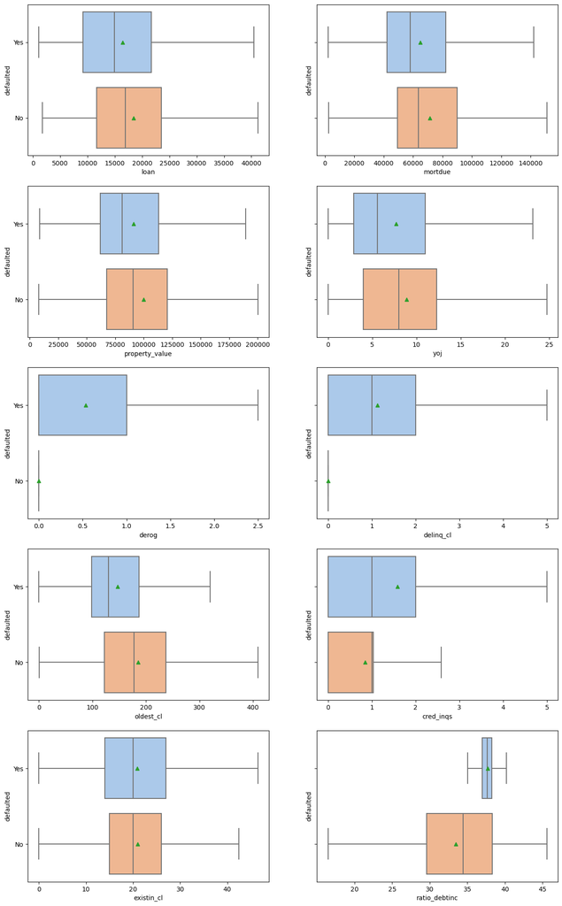

```python
# Plotting variables
fig, ax = plt.subplots(5,2, figsize=(15,25), sharey=True)
for i in range(2):
    for j in range(5):
        sns.boxplot(data=df, x = df[ls[j,i]] , y ='defaulted', palette ='pastel', showmeans=True, ax=ax[j][i])
```

We can notice that for some variables, the distribution grouped by default are vastly different. This patter in distribution is crucial for the classification model performance.

## Data preparation

In order to extract meaningful information from data it is necessary to encode categorical variables into binary values. Next, it is done the encoding of categorical variables. Job is treated apart since it has multiple categories we want to preserve.

```python
# Encoding categorical variables with more than 2 categories
ndf = pd.get_dummies(df.iloc[:,df.columns == 'job'])

# Encoding variables with binary information (defaulted and reason)
cdf = pd.get_dummies(df.iloc[:,df.columns != 'job'], drop_first=True)

# Concatenating previous dataframes with encoded information
ddf = pd.concat([ndf, cdf], axis=1)

# Renaming target variable
ddf.rename(columns = {'defaulted_Yes' : 'defaulted'}, inplace=True)
```

At this point, we will separate the target variable from the data set and split the data into training and testing dataset with a ratio of 70%-30%, respectively.

```python
# Separate independent and dependent variables
y = ddf['defaulted'].copy()
x = ddf.copy().drop(columns= ['defaulted'])

# Split dataset into training and testing data
x_train, x_test, y_train, y_test = train_test_split(x,y, test_size=0.3, shuffle=True, random_state=1)
```

## Model evaluation criterion

**Model evaluation criterion**

Next, it is stated the possible predictions for this case and the most important situations in order to minimize the risk of default.

Possible wrong predictions:

1. The model predicts that a client will default on its loan, but the client actually paid the loan.
2. The model predicts that a client will pay its loan, but the client defaulted on its loan.

Which case is more important?

- In the first scenario, the bank would not approve the loan and might lose money from interest.
- In the second scenario, the bank would approve the loan and lose that money plus the interest.

Hence, the second scenario is more important since the bank would lose more money in the case of approving the loan. Thus, in order to minimize the probabilities of false-negative cases, **recall score should be maximized.**

**Confusion matrix:**

- **True-Positive:** Predicting that the client will default on its loan and actually does.
- **True-Negative:** Predicting that clients will pay their loan and they actually does.
- **False-Positive:** Predicting that the client will default on loan but actually paid its loan.
- **False-Negative:** Predicting that the client will pay its loan but the client defaulted on its loan.

Once it is established the criteria for the classification algorithms, we proceed to build the models. First, it is defined some functions to meassure the model performance and to plot confussion matrix.

```python
def model_performance(model, predictors, target):
    """
    Function to compute different metrics to check classification model performance
    model: fitted classifier
    predictors: independent variables
    target: dependent variable
    """
    # Predicting values using the independent variables
    pred = model.predict(predictors)

    # Computing F1-score
    f1 = f1_score(target, pred)
    # Computing Recall score
    recall = recall_score(target, pred, average = 'macro')
    # Computing Precision score
    precision = precision_score(target, pred, average = 'macro')
    # Computing Accuracy score
    acc = accuracy_score(target, pred)

    # Creating a dataframe of metrics
    df_perf = pd.DataFrame({'Precision':  precision,
                            'Recall':  recall,
                            'Accuracy': acc,
                            'F1-score': f1} ,index = ['Score'])
    return df_perf


def conf_matrix(model):
    '''
    Function to plot confusion matrix of both training and testing data.

    model: fitted classifier.
    '''
    # Setting list with training and testing data
    xy_data = [[x_train, y_train], [x_test, y_test]]

    # Setting subplot axes for plots
    fig, ax = plt.subplots(1,2, figsize=(15,6), sharey=True)
    for i in range(2):
        # Predicting values on training and testing data
        y_pred = model.predict(xy_data[i][0])

        # Generating confussion matrix
        cm = confusion_matrix(xy_data[i][1],y_pred)

        # Plotting confussion matrix on a heatmap
        sns.heatmap(cm, annot = True,  fmt = '.2f',
                    xticklabels = ['Defaulted', 'Paid'], yticklabels = ['Defaulted', 'Paid'],
                    cmap=sns.cubehelix_palette(as_cmap=True), cbar=True, ax=ax[i])

    # Settiing titles
    fig.suptitle('Confusion matrix', fontsize=20)
    ax[0].set_title('Training data', fontsize=15)
    ax[1].set_title('Testing data', fontsize=15)


# Getting a list with column names from the dependent variable
features = x.columns.tolist()
def tree_plot(model):
    '''
    Function to plot the specified model decision tree with depth 3
    model: Fitted classifier
    '''
     # Plotting decision tree with depth = 3
    plt.figure(figsize=(20,10))
    tree.plot_tree(model, feature_names = features, max_depth=3,
                   filled = True, fontsize = 10,
                   node_ids = False, class_names = ['Defaulted', 'Paid'], label='root')


def importance(model):
    '''
    Function to plot the feature importance from the specified model
    model: Fitted classifier.
    '''
    # Getting importances
    importances = model.feature_importances_

    # Creating a dataframe with sorted feature importances
    imp_df = pd.DataFrame(importances, index=features, columns=['Importance']).sort_values(by='Importance', ascending=False)

    # Plotting importances
    plt.figure(figsize=(8,6))
    sns.barplot(x=imp_df.Importance, y=imp_df.index, palette='pastel')
    plt.title('Feature importance', fontsize=20)
    plt.xlabel('Importance')
```

## Building a decision tree model

Once the data is split and ready, we proceed to build the decision tree by calling the scikit learn class, DecisionTreeClassifier. As previously stated, aproximately 80% of clients repaid their loans, which means that the target variable is imbalanced. Hence, as a first parameter for the classifier we want to balance the data by setting weights for the defaulted status as follows: 0.2 for class 0 (paid status) and 0.8 for class 1 (defaulted status).

```python
# Setting the class with a reproducible random state.
d_tree = tree.DecisionTreeClassifier(random_state=1,class_weight= {0: 0.2, 1: 0.8})

# Fitting the decision tree model to our training set.
d_tree.fit(x_train, y_train)
```

```
DecisionTreeClassifier(class_weight={0: 0.2, 1: 0.8}, random_state=1)
```

Following with the model construction, in order to analyze wheter the model is overfitting or not, we will compare the performance on both the training and testing dataset. First, it is printed the specific parameters for further analysis and comparison.

```python
# getting the depth of the fitted model
d_tree.get_depth()
```

```
19
```

```python
# Fitted decision tree depth
d_tree.get_params()
```

```
{'ccp_alpha': 0.0,
 'class_weight': {0: 0.2, 1: 0.8},
 'criterion': 'gini',
 'max_depth': None,
 'max_features': None,
 'max_leaf_nodes': None,
 'min_impurity_decrease': 0.0,
 'min_samples_leaf': 1,
 'min_samples_split': 2,
 'min_weight_fraction_leaf': 0.0,
 'random_state': 1,
 'splitter': 'best'}
```

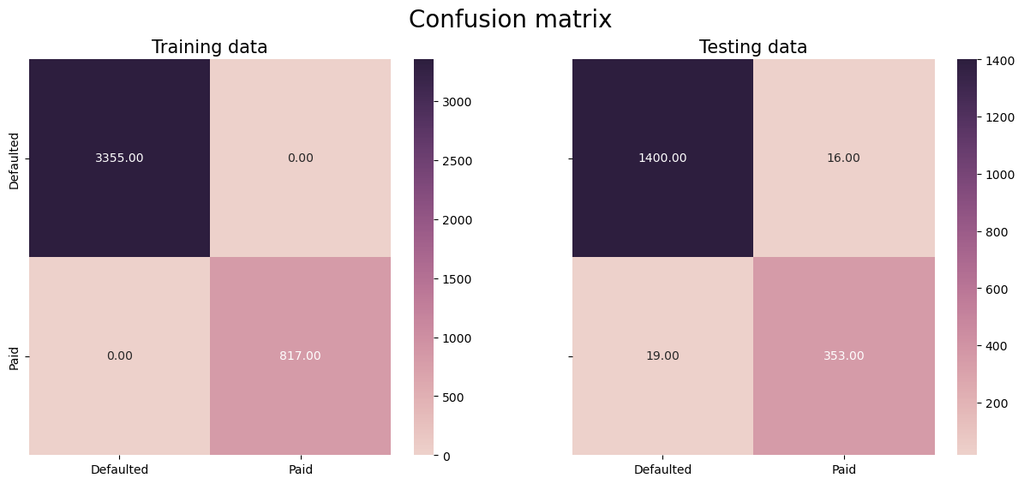

```python
# Plotting confusion matrix of training and testing data
conf_matrix(d_tree)
```

```python
# Printing model performance metrics on training data
model_performance(d_tree, x_train, y_train)
```

|  | Precision | Recall | Accuracy | F1-score |
| --- | --- | --- | --- | --- |
| Score | 1.0 | 1.0 | 1.0 | 1.0 |

```python
# Printing model performance metrics on testing data
dtree_test = model_performance(d_tree, x_test, y_test)
dtree_test
```

|  | Precision | Recall | Accuracy | F1-score |
| --- | --- | --- | --- | --- |
| Score | 0.971625 | 0.968813 | 0.980425 | 0.952767 |

### Observations:

- Given that the model is perfectly predicting outputs in the training data but fails to match the performance on the testing data, the model is overfitting.
- However, the performance on the testing data is good since it achieved a recall score of 0.96.
- The depth of the fitted model is 19 which could possibly be pruned.

Even though the model is overfitting we can still visualize the decission tree itself and make some assumptions. Below is plotted the first three nodes from the decision tree as well as the feature importance.

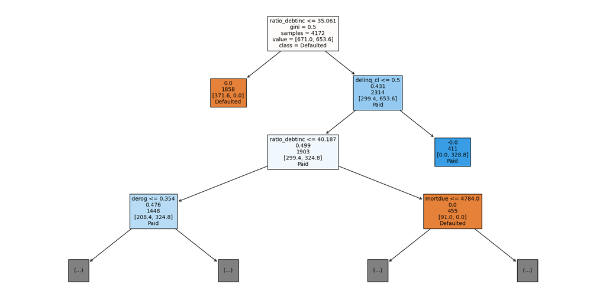

```python
# Plotting first 3 nodes from the decision tree built
tree_plot(d_tree)
```

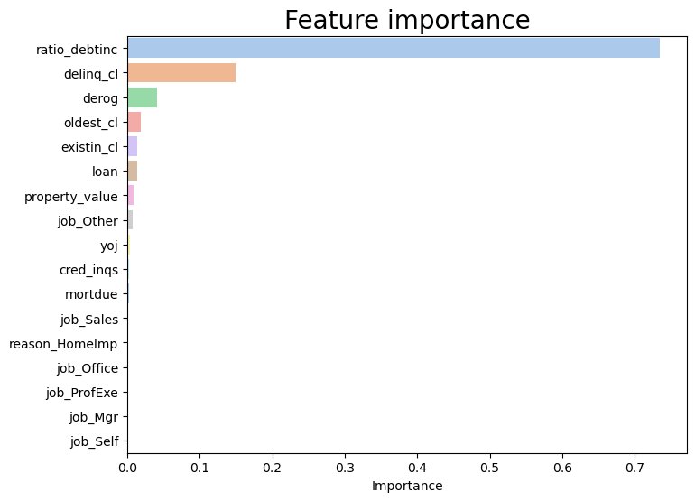

```python
# Plotting feature importances for the tuned model
importance(d_tree)
```

### Observations:

- We can notice that the model is highly biased since it is making predictions mostly based on one variable (debt-to-income ratio).
- On the other hand, as it was expected from the previous analysis, the top tree variables on the model are the debt-to-income ratio, the number of delinquent credit lines and the number of derogatory reports.

## Decision tree hyperparameter tuning

In order to avoid the model from overfitting it is done below the corresponding fine tuning of hyperparameter. We will make use of GridSearchCV method from Scikit learn to prune the tree, moreover the chosen parameter are the maximum depth, split criterions, minimum samples in leaf node and the maximum features when looking for the best split.

```python
# Adjusting class weights on the classifier
d_tree_tuned = tree.DecisionTreeClassifier(random_state=1, class_weight= {0: 0.2, 1: 0.8})

# Grid of hyperparameters to chose
parameters = {'max_depth': np.arange(10,14),
              'criterion': ['entropy','gini'],
              'min_samples_leaf': np.arange(5,15),
              'max_features': ['auto', 'sqrt']
             }

# Scoring to compare the parameter combinations. Recall-score for class 1 in this case
scorer = metrics.make_scorer(recall_score, pos_label=1)

# Running Grid search
grid_obj = GridSearchCV(d_tree_tuned, parameters, scoring=scorer, cv=7)

grid_obj = grid_obj.fit(x_train, y_train)

# Select the best estimator i.e. the tree with highest F1-score
d_tree_tuned = grid_obj.best_estimator_
print(grid_obj.best_params_)
# Fit the training data to the best estimator
d_tree_tuned.fit(x_train, y_train)
```

```
{'criterion': 'entropy', 'max_depth': 11, 'max_features': 'auto', 'min_samples_leaf': 7}
```

```
DecisionTreeClassifier(class_weight={0: 0.2, 1: 0.8}, criterion='entropy',
                       max_depth=11, max_features='auto', min_samples_leaf=7,
                       random_state=1)
```

```python
# Parameters chosen to get the best estimator
print(grid_obj.best_params_)
```

```
{'criterion': 'entropy', 'max_depth': 11, 'max_features': 'auto', 'min_samples_leaf': 7}
```

```python
# getting the depth of the tree
d_tree_tuned.get_depth()
```

```
11
```

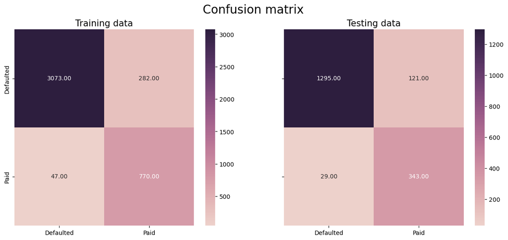

```python
# PLotting confusion matrix for the tuned model
conf_matrix(d_tree_tuned)
```

```python
# Printing tuned model performance on training data
model_performance(d_tree_tuned, x_train, y_train)
```

|  | Precision | Recall | Accuracy | F1-score |
| --- | --- | --- | --- | --- |
| Score | 0.858438 | 0.929209 | 0.921141 | 0.82397 |

```python
# Printing tuned model performance on testing data
dtree_tuned_test = model_performance(d_tree_tuned, x_test, y_test)
dtree_tuned_test
```

|  | Precision | Recall | Accuracy | F1-score |
| --- | --- | --- | --- | --- |
| Score | 0.85866 | 0.918296 | 0.916107 | 0.820574 |

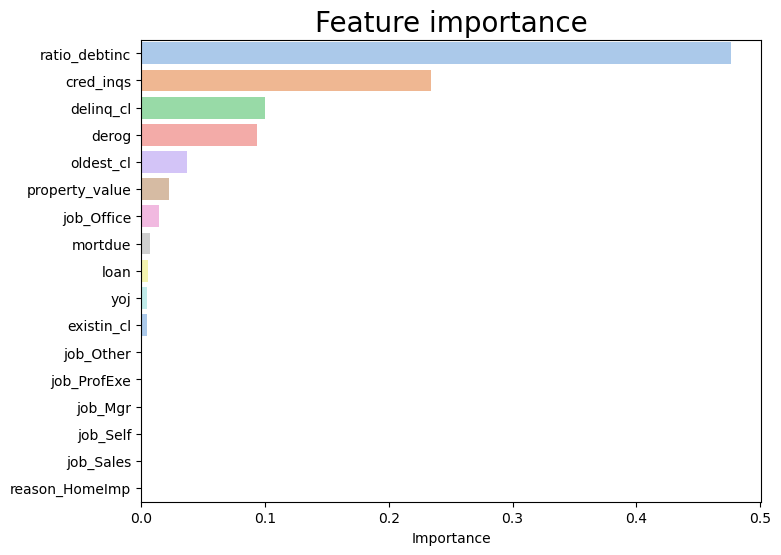

```python
# Plotting feature importances for the tuned model
importance(d_tree_tuned)
```

### Observations:

- As expected, the performance on the training data has decreased in comparison with the default decision tree settings. Specifically, recall score decreased from 1 to 0.92 in the training data.
- On the other hand, now the model is not overfitting since the recall score for both datasets are relatively close, meaning that the model is able to generalize.
- Regarding the feature importances, we observe that the importance of some variables has increased. The model is less biased and makes predictions based on more variables.

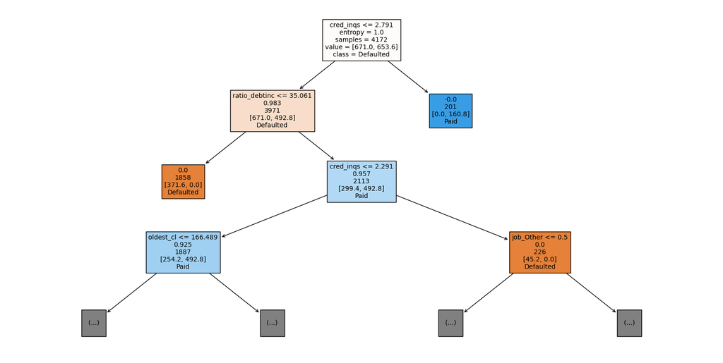

```python
# Plotting first 3 nodes from the decision tree built
tree_plot(d_tree_tuned)
```

## Building a random forest model

Following up with model construction, it is time to build a random forest and analyze its performance on both the training and testing datasets.

```python
# Initialize random forest
rf_clf = RandomForestClassifier(random_state=1, class_weight= {0: 0.2, 1: 0.8})

# Fitting model into the training data
rf_clf.fit(x_train, y_train)
```

```
RandomForestClassifier(class_weight={0: 0.2, 1: 0.8}, random_state=1)
```

```python
# parameter from the fitted random forest
rf_clf.get_params()
```

```
{'bootstrap': True,
 'ccp_alpha': 0.0,
 'class_weight': {0: 0.2, 1: 0.8},
 'criterion': 'gini',
 'max_depth': None,
 'max_features': 'sqrt',
 'max_leaf_nodes': None,
 'max_samples': None,
 'min_impurity_decrease': 0.0,
 'min_samples_leaf': 1,
 'min_samples_split': 2,
 'min_weight_fraction_leaf': 0.0,
 'n_estimators': 100,
 'n_jobs': None,
 'oob_score': False,
 'random_state': 1,
 'verbose': 0,
 'warm_start': False}
```

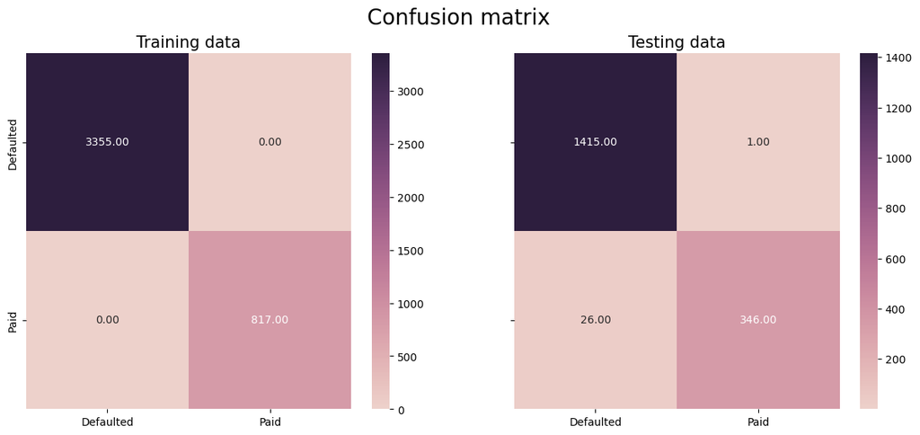

```python
# Plotting confusion matrix of training and testing data
conf_matrix(rf_clf)
```

```python
# Printing performance of random forest on trainig data
model_performance(rf_clf, x_train, y_train)
```

|  | Precision | Recall | Accuracy | F1-score |
| --- | --- | --- | --- | --- |
| Score | 1.0 | 1.0 | 1.0 | 1.0 |

```python
# Printing performance of random forest on trainig data
rf_test = model_performance(rf_clf, x_test, y_test)
rf_test
```

|  | Precision | Recall | Accuracy | F1-score |
| --- | --- | --- | --- | --- |
| Score | 0.989538 | 0.964701 | 0.984899 | 0.962448 |

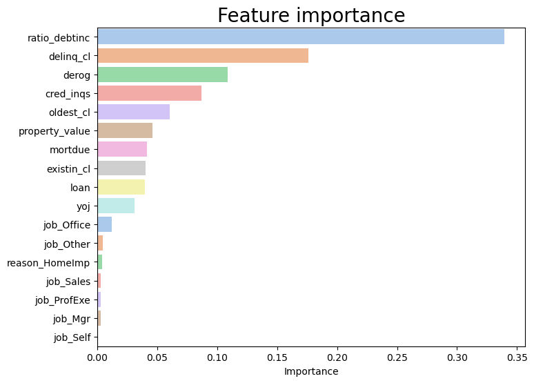

```python
# Plotting feature importances
importance(rf_clf)
```